# Advanced Biostatistics for HDS Assessment

Candidate Number 7524

## 1. Data Exploration and Cleaning

Upon inspecting the data, a protocol deviation at site C was identified. The biomarker tx181 was coded as -1 for all 4,148 site C children at both visits, and rg67 was entirely missing (NA) for site C at both visits. Additionally, the rg array contains 5 biomarkers rather than the documented 6, documentin a further variable lost. A single invalid LivingBarriers value of -1 was also identified (site C, visit 4), these were recoded as NA. Negative values in rg9 were investigated but found across all regions proportionally so we decided to retain them. The site C missingness is systemic, consistent with a Missing Completely At Random (MCAR) mechanism, as it is driven by site-level protocol differences rather than participant characteristics or outcomes.

```r
data$LivingBarriers[data$LivingBarriers == -1] <- NA
bloods$V1.tx181[bloods$Region == "C"] <- NA
bloods$V3.tx181[bloods$Region == "C"] <- NA
```

Participants have between 4 and 7 visits, approximately annually spaced (mean interval 365 days, SD 25 days). Not all participants complete all visits: all 12,338 attend visits 1 to 4, but only 7,915 reach visit 5, 3,335 reach visit 6, and 1,058 reach visit 7. Dropout is evenly distributed across regions, but participants who remain in the study longer have higher baseline LivingBarriers scores (mean 41.2 for 4-visit participants vs 49.3 for 7-visit participants). This suggests dropout is related to the outcome, making a MCR assumption unlikely. A Missing At Random (MAR) mechanism is more plausible, which has implications for our investigating approach.

## 2. RQ1: How do barriers to childhood living change over time?

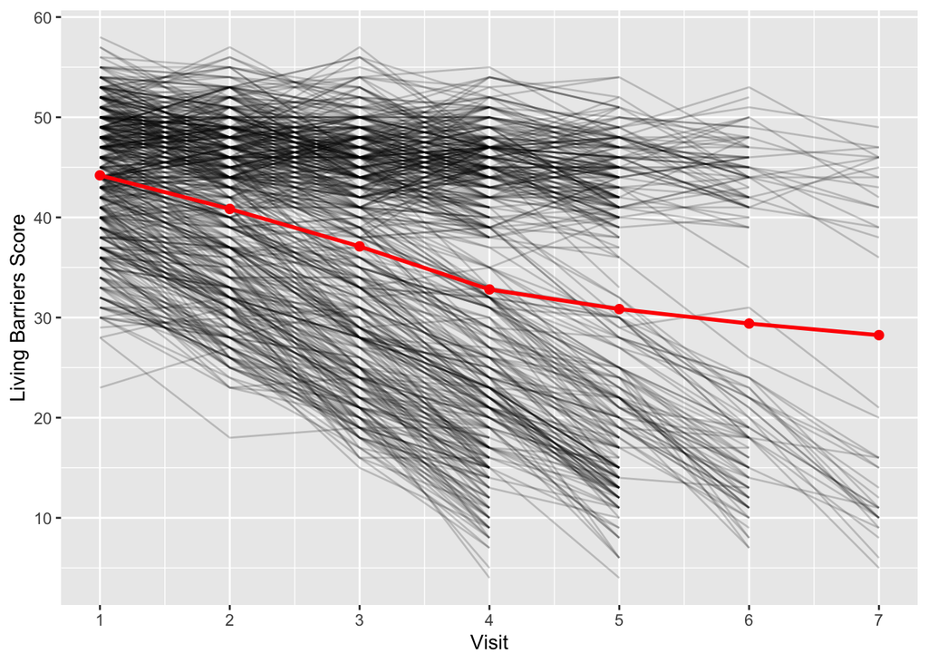

**Figure 1: Individual trajectories (grey) and mean trajectory (red).**

Mean LivingBarriers declines from 44.2 at visit 1 to 28.2 at visit 7, and the rate of decline appears to slow at later visits. Individual trajectories show significant variability in both starting level and rate of change, motivating the use of random intercepts and random slopes. The MAR dropout pattern identified in Section 1 motivated the use of linear mixed models, which provide valid inference under MAR through likelihood-based estimation. This was preferred over Generalised Estimating Equations (GEEs), which require the stricter MCAR assumption and estimate population-average rather than subject-specific effects.  
**Model 1: Random intercept only** — each child has their own baseline but all decline at the same rate.

```r
m1 <- lmer(LivingBarriers ~ Visit + age_c + Gender + (1 | ID), data = data)
summary(m1)
```

Age at entry and gender were included as fixed effects as potential confounders. The average barriers for a male child of average age is 50.5 at visit 1, declining by 3.9 points per visit. Each additional year of age at entry is associated with 4.0 fewer barriers, and females and gender diverse participants report 2.3 and 2.9 fewer barriers respectively. The random intercept SD (9.02) is large relative to the residual SD (5.23), indicating substantial between-child variation. However, this model assumes all children decline at the same rate but looking at Figure 1 above it suggests otherwise.  
**Model 2: Random intercept + random slope** — each child has their own rate of change too.

```r
m2_gender <- lmer(LivingBarriers ~ Visit + age_c + Gender + (Visit | ID), data = data)
summary(m2_gender)
AIC(m1, m2_gender)
BIC(m1, m2_gender)
```

**Model 3 & 4: Checking for Region**

```r
# testing if region has any impact
m3 <- lmer(LivingBarriers ~ Visit + age_c + Region + (Visit | ID), data = data)
m4 <- lmer(LivingBarriers ~ Visit * Region + age_c + (Visit | ID), data = data)
AIC(m2, m3, m4)
BIC(m2, m3, m4)
```

Region was tested as a fixed effect to assess whether sites differ in their average barrier level (m3) or rate of change (m4: Region × Visit interaction). Neither improved model fit (AIC: m2 = 353,723, m3 = 353,731, m4 = 353,741; BIC supports). The trajectory of barriers is consistent across all three sites.  
**Model 5: Quadratic time effect** — the mean trajectory appeared to flatten at later visits.

```r
data$Visit2 <- data$Visit^2
# ML for comparing models with different fixed effects
m2_ml <- lmer(LivingBarriers ~ Visit + age_c + (Visit | ID), data = data, REML = FALSE)
m5_ml <- lmer(LivingBarriers ~ Visit + Visit2 + age_c + (Visit | ID), data = data, REML = FALSE)
AIC(m2_ml, m5_ml)
BIC(m2_ml, m5_ml)
anova(m2_ml, m5_ml)
```

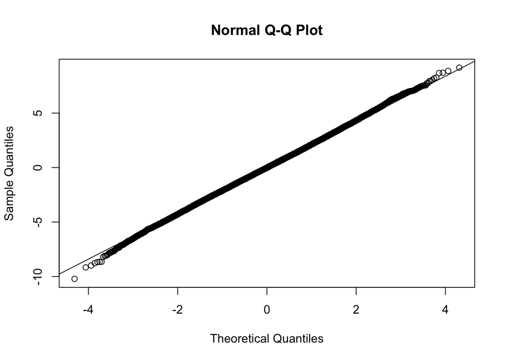

**Figure 2: QQ plot of residuals from the quadratic random slope model (m5).**

The QQ plot shows approximate normality with minor deviations in the tails. Residuals versus fitted values were also checked and displayed no systematic pattern.

For a sensitivity analysis, the model was refitted using only visits 1 to 4, where all 12,338 participants are observed and no missing data assumptions are required. The fixed effect estimates were closely comparable (visit: −2.61 vs −2.75; age: −2.95 vs −3.01), supporting the plausibility of the MAR assumption.

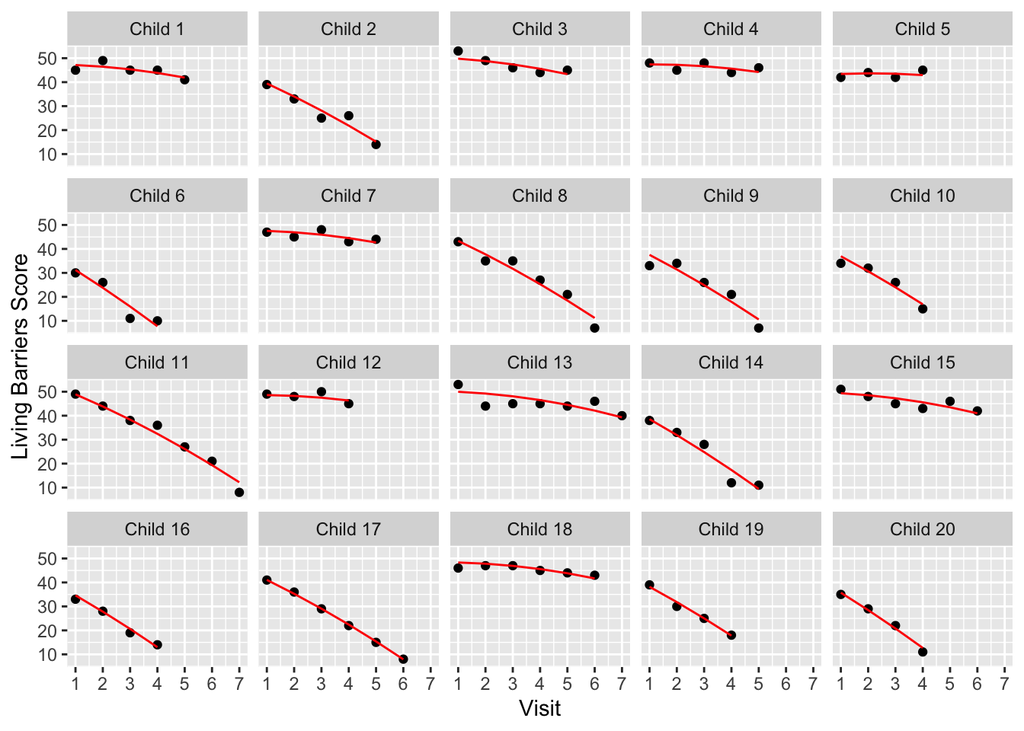

**Figure 3: Observed values (points) and child specific predicted trajectories (red) for 20 randomly sampled children**

There is substantial heterogeneity between children as some improve rapidly while others show little change, captured by the random intercepts and slopes in the model. The pattern is consistent across all three study sites. A key limitation is the reliance on the MAR assumption, though the sensitivity analysis above suggests this is plausible. If dropout is instead related to unobserved outcomes (MNAR), the estimated trajectories may underestimate the true rate of decline. Also, LivingBarriers is self-reported and may be subject to reporting bias. Gender was explored but found not to be significant once individual trajectories were accounted for.

## 3. RQ2: Do biomarkers identify subgroups responding differently to standard care?

The blood dataset contains 11 biomarkers measured at visits 1 and 3 across two arrays (tx: 6 markers, rg: 5 markers). As identified in Section 1, site C is missing tx181 and rg67 at both visits which is a structural, site-level pattern consistent with MCAR. To avoid excluding site C, imputation by chained equations (MICE) was used to retain all participants and biomarkers. Region was included as a predictor in the imputation model (but not imputed itself) since it determines the missingness pattern.

```r
# seet up imputation methods
imp_method <- make.method(bloods)
imp_method["ID"] <- "" # don't impute id
imp_method["Region"] <- "" # don't impute region

# predictor matrix
imp_pred <- make.predictorMatrix(bloods)
imp_pred["ID", ] <- 0 # id not being imputed
imp_pred[, "ID"] <- 0 # id not used as predictor for anything

imp_pred["Region", ] <- 0 # region not being imputed but used as predictor for missing biomarkers

set.seed(123) # to fix for future iterations
imp <- mice(bloods, m = 10, maxit = 20, method = imp_method,
            predictorMatrix = imp_pred, printFlag = FALSE)
```

Predictive mean matching (PMM) was used to generate 10 multiply imputed datasets, each providing values for the 4 missing biomarker variables in site C. The imputed distributions closely matched the observed values from sites A and B (e.g., V1.tx181 mean: 32.94 imputed vs 32.97 observed), supporting the MCAR assumption.

To identify biomarker defined subgroups, clustering was performed on the 11 biomarkers measured at visit 1. K-means and model-based clustering (Gaussian mixture model, `mclust`) were both considered. However, Professor Kirk just hates K-means so let’s not fight with watermills here. Model-based clustering was preferred as it simultaneously selects the number of clusters and the covariance structure via BIC, allowing clusters to differ in size and shape. Two subgroups were identified: 6,004 and 6,334 children.

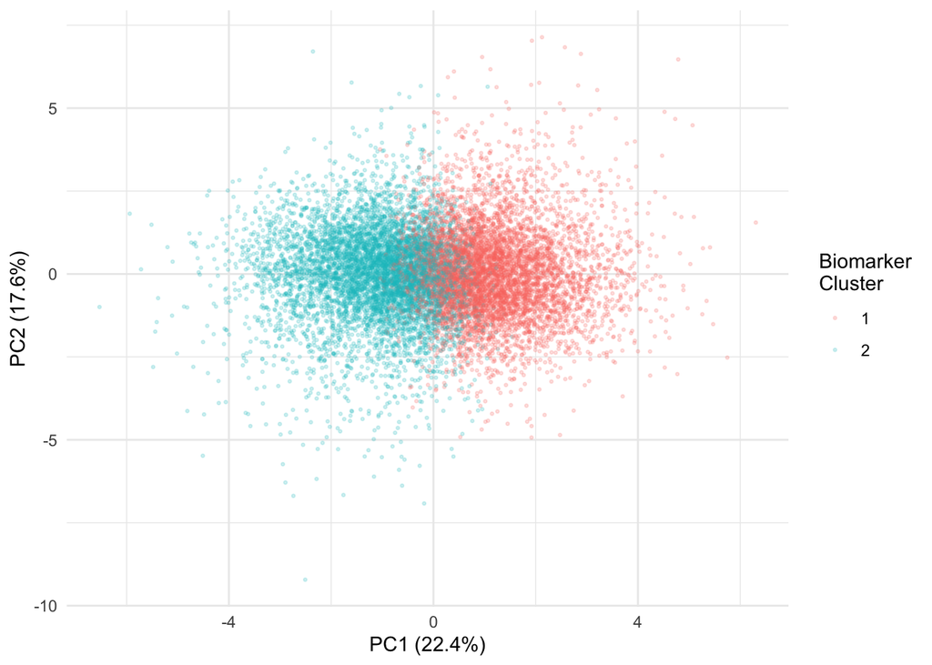

**Figure 4: PCA of visit 1 biomarkers coloured by cluster classification**

PCA was used to visualise the clusters in reduced dimensions. The first two components explain 40% of the total variance — PC1 (22.4%) is driven by the tx array markers (tx9, tx165, tx166, tx83), while PC2 (17.6%) captures a contrast within the rg array.

The two groups are not quite sharply separated as we would hope for, reflecting gradual rather than discrete differences in biomarker profiles. Neverthless, the cluster classification was added to the mixed model from RQ1 to test whether these groups respond differently to standard care.

**Mixed model with cluster interactions**

```r
# fit mixed model with cluster interactions
m_clust <- lmer(LivingBarriers ~ Visit * Cluster + Visit2 * Cluster + age_c +
                  (Visit | ID), data = data_clust, REML = TRUE)

summary(m_clust)
```

Both interaction terms were significant: cluster 2 children began with fewer barriers (−0.79, t = −8.0) and showed a steeper decline over time (visit × cluster: −0.56, t = −7.1; visit² × cluster: −0.06, t = −6.1).

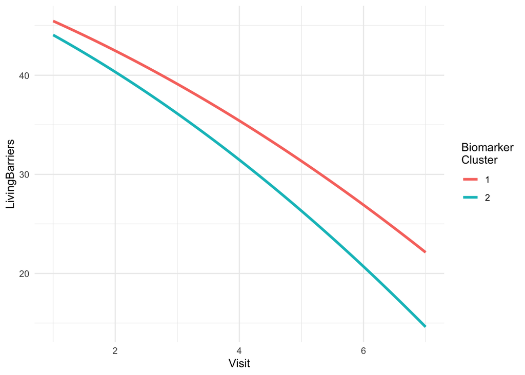

**Figure 5: Predicted LivingBarriers trajectories by biomarker cluster for a child of average age at entry**

Biomarker defined subgroups thus provide evidence that children with different biological profiles at visit 1 respond differently to standard care. Cluster 2 is characterised by higher tx9 and tx166 which shows both lower initial barriers and a faster rate of improvement, suggesting these markers may have value in identifying children likely to benefit most from standard care.

Several limitations have to be noted. The clusters overlap substantially, reflecting gradual shifts in biomarker levels rather than discrete biological subtypes. Clustering was performed on a single completed dataset, and while Rubin’s rules allow pooling of model estimates across imputations, there is no standard method for pooling cluster tasks, and results showed some sensitivity to the imputed values used. The rg array contains 5 rather than the documented 6 biomarkers, suggesting one variable was not collected and cannot be recovered. Finally, the causal direction is unclear as the biomarker differences may reflect underlying health status rather than directly influencing response to care.

Number of words: 1584

AI Statement: LLM was used to refine and tighten sentences in my draft to meet the word limit.